# ADGRs in lymphatic endothelial cells in scRNA-seq datasets

- Show All Code
- Hide All Code
- View Source

Author

Heli Xu

```r
library(dplyr)
library(Seurat)
library(ggplot2)
```

## Dataset1: postMI mice heart (Farbehi et al. 2019)

### Identification of LEC clusters

The paper did not include cell type information in the dataset, so we will use established markers to define endothelial cells (EC) and lymphatic endothelial cells (LEC).

Here, we are checking the distribution and expression levels of known EC markers (Pecam1, Icam2, Cdh5) among all clusters of cells to identify EC clusters.

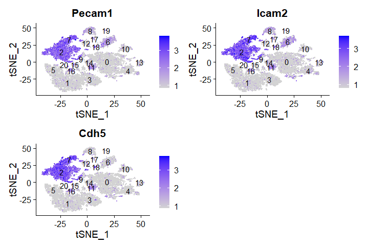

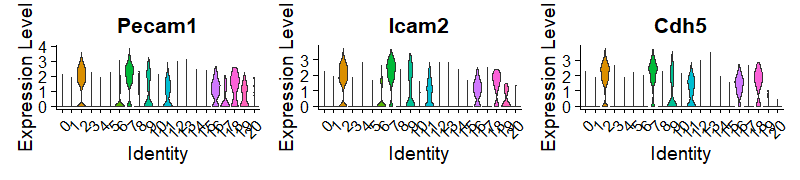

Based on the plots, we’ll define cluster 2, 7, 9, 12, 15, 18, 19 as EC.

Among them, we’ll use LEC lineage markers to identify possible LEC populations. Markers used include: Pdpn, Flt4, Prox1, Ackr4, Msr1, Fcgr2b, Lyve1, Fth1

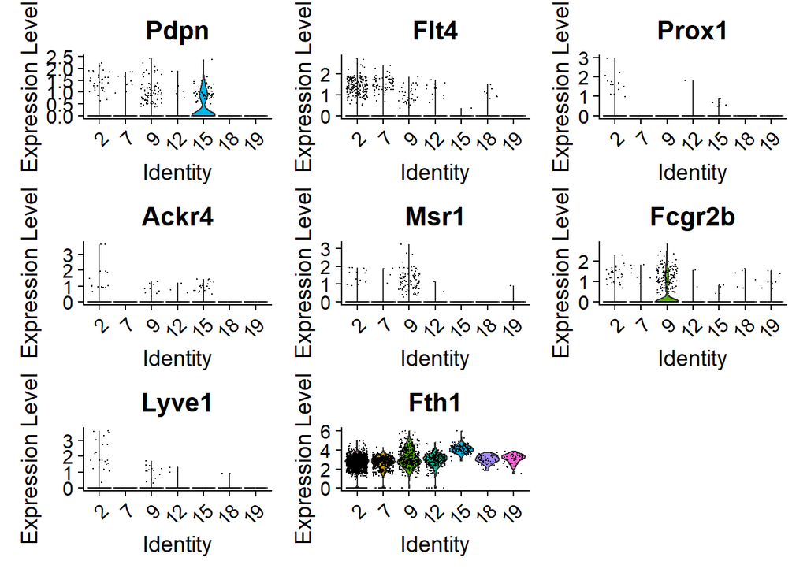

```r
load("../data/healthy MI non myocyte cardiac/clean/MI_EC_orig_ident.rdata")
##this is EC subset without changing idents to "sample"!

VlnPlot(TIP_MI_EC,
        features = c("Pdpn","Flt4","Prox1","Ackr4","Msr1","Fcgr2b",
                     "Lyve1", "Fth1"),
        pt.size = 0.1)
```

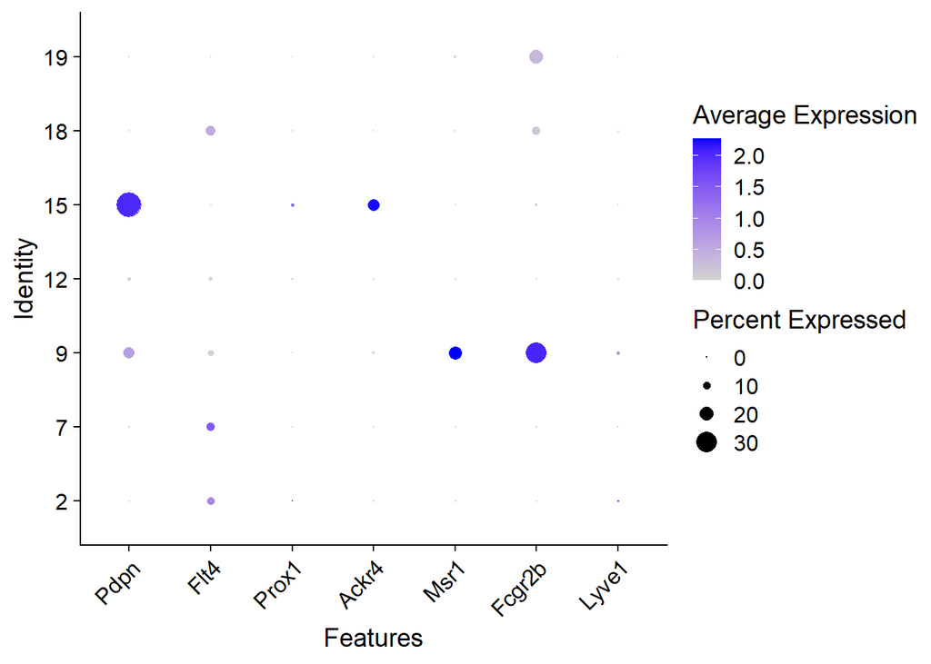

```r
DotPlot(TIP_MI_EC,
        features = c("Pdpn","Flt4","Prox1","Ackr4","Msr1","Fcgr2b",
                     "Lyve1"),
        col.min = 0, col.max = 3,
        dot.min = 0, dot.scale = 6)+
  theme(axis.text.x = element_text(angle = 45, vjust = 1, hjust=1))
```

*note that Fth1 is not shown in the dot plot to visualize the less expressed markers.

It looks like the cluster 9 and 15 are likely to be LEC. Firstly, we’ll plot all the ADGRs (33 in total) in EC to put it in perspective. (When all cells show same value of expression for a gene, it usually means the gene is minimally expressed, and therefore with scaling the values become quite indistinguishable. )

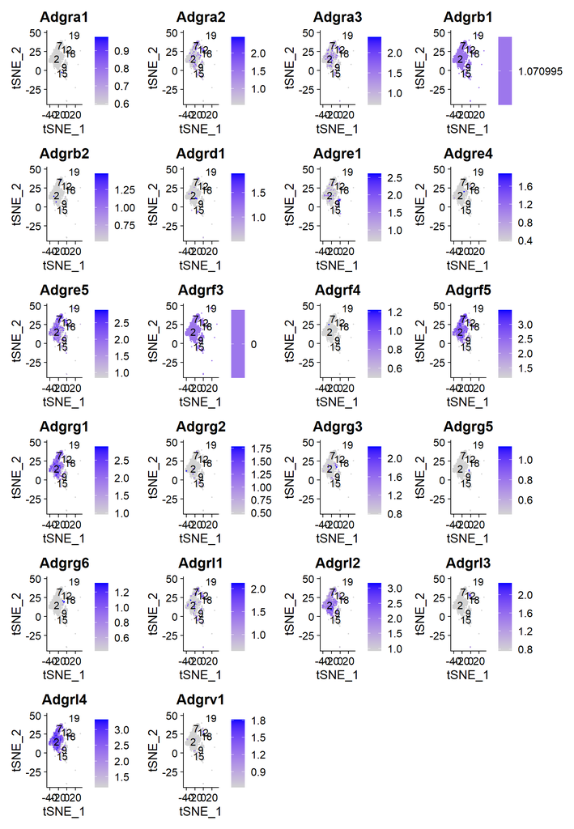

```r
ADGR_list <- c("Adgra1", "Adgra2","Adgra3", "Adgrb1","Adgrb2", "Adgrb3", "Adgrc3","Adgrc1", "Adgrc2", "Adgrd1", "Adgrd2", "Adgre1", "Adgre2", "Adgre3", "Adgre4", "Adgre5", "Adgrf1", "Adgrf2", "Adgrf3", "Adgrf4","Adgrf5","Adgrg1","Adgrg2","Adgrg3", "Adgrg4", "Adgrg5", "Adgrg6", "Adgrg7","Adgrl1", "Adgrl2", "Adgrl3", "Adgrl4", "Adgrv1")

FeaturePlot(TIP_MI_EC,
            reduction = "tsne",
            features= ADGR_list,
            sort.cell = TRUE,
            min.cutoff = 'q10',
            label = TRUE)
```

Other than the 11 undetectable ADGRs, several ADGRs show very low expression level (in few cells) in the plot above. We’ll narrow the list down (Adgra2, Adgra3, Adgrb1, Adgre1, Adgre5, Adgrf5, Adgrg1, Adgrg3, Adgrl1, Adgrl2, Adgrl4) and look further below.

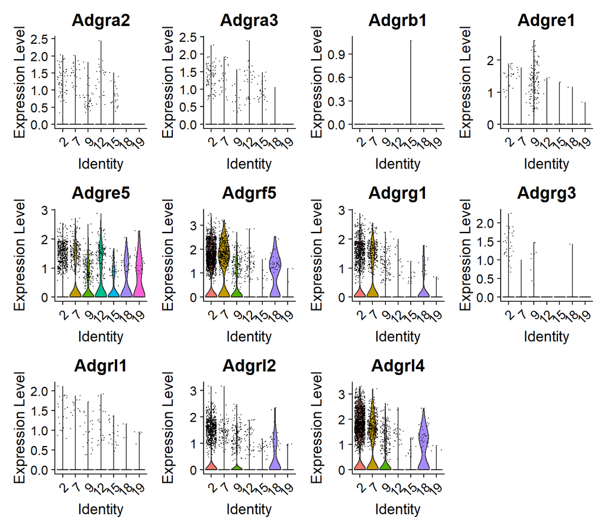

```r
VlnPlot(TIP_MI_EC,
        features= c("Adgra2", "Adgra3", "Adgrb1",
                    "Adgre1", "Adgre5", "Adgrf5",
                    "Adgrg1", "Adgrg3","Adgrl1",
                    "Adgrl2", "Adgrl4"))
```

Adgrb1 barely shows up in the violin plot and could be excluded from further examination, but we are keeping it for its (very low) expression in cluster 15 (LEC).